# Project: Test a Perceptual Phenomenon by Michael Eryan

### Introduction

#### The data we have is from a kind of “Stroop” test in which each subject was given two lists of words containing only color names. One list had congruent words (the word matched the color of letters) and the other one had incongruent words.

### Question 1: Identify variables in the experiment

#### A1: The indendendent variable is the type of the list of words given to the subjects - congruent or incongruent. The dependent variable is the time it took the subjects to name the ink colors of the words in the lists.The time is presumed to be measured in seconds. Unit of observation is the individual subject participating in the test.

### Question 2: Establish a hypothesis and statistical test

#### A2a:

#### Null hypothesis (H0): µ_congruent = µ_incongruent

#### Alternative hypothesis (H1): µ_congruent < µ_incongruent

#### Where “µ” is the real and unknown average time it takes people in general (not just in our sample but in the whole world) to name the ink colors from each list. This “µ” is an unseen parameter, not to be confused with X_bar which is the observed sample mean statistic.

#### My null hypothesis (H0) is that there there is no difference in the time it takes people (the population in general, not our sample) to name the ink colors for the two lists. My alternative hypothesis (H1) is one-sided - that it takes a longer time for people to name the ink colors from the incongruent list because the mismatch between the two messages (the meaning of the word and the color of the ink it was written with) would lead to more mental activity and, therefore, longer processing time.

#### A2b:

#### Given that the observations (subjects) are independent of each other, a parametric test of means is appropriate.

#### Since each subject was given two treatments, this calls for a paired test of means. Because my alternative is in one direction, the test will be one sided (“greater”).

#### Why did I choose to do a T-test instead of a Z-test?

#### Because T-test is more appropriate when a). sample size is small - only 24 observations in our case. b). because we have to use the sample standard deviation as an estimate of the unknown (and impossible to get) population standard deviation that is needed to calculate our test statistic.

```r
#R-code
setwd('C:\\Users\\rf\\Google Drive\\Education\\R\\Udacity\\stroop')

#Load all libraries on top
suppressPackageStartupMessages(library(ggplot2))
suppressPackageStartupMessages(library(reshape))

#Manual input required - the name of the file
tinput = 'stroopdata.csv'
t <- read.csv(tinput)

# Data Preparation
# Add a row id, rename columns, calculate averages, variances, differences.
colnames(t) = c('con','inc')
t$id = 1:nrow(t)
t$d = t$inc - t$con
attach(t)

#print (summary(t))

conmu = round(mean(con),4)
incmu = round(mean(inc),4)
convar = round(var(con),4)
incvar = round(var(inc),4)
dmu = round(mean(d),4)
dvar = round(var(d),4)
```

### Question 3: Report descriptive statistics

#### A3: please see the output from R below

```
## [1] "The mean time for the congruent list was 14.0511 seconds with the variance of 12.669"
```

```
## [1] "While the mean time for the incongruent list was 22.0159 seconds with the variance of 23.0118"
```

```
## [1] "The mean difference between incongruent and congruent was 7.9648 seconds with the variance of 23.6665"
```

### Question 4: Plot the data

#### A4: please see the output from R below

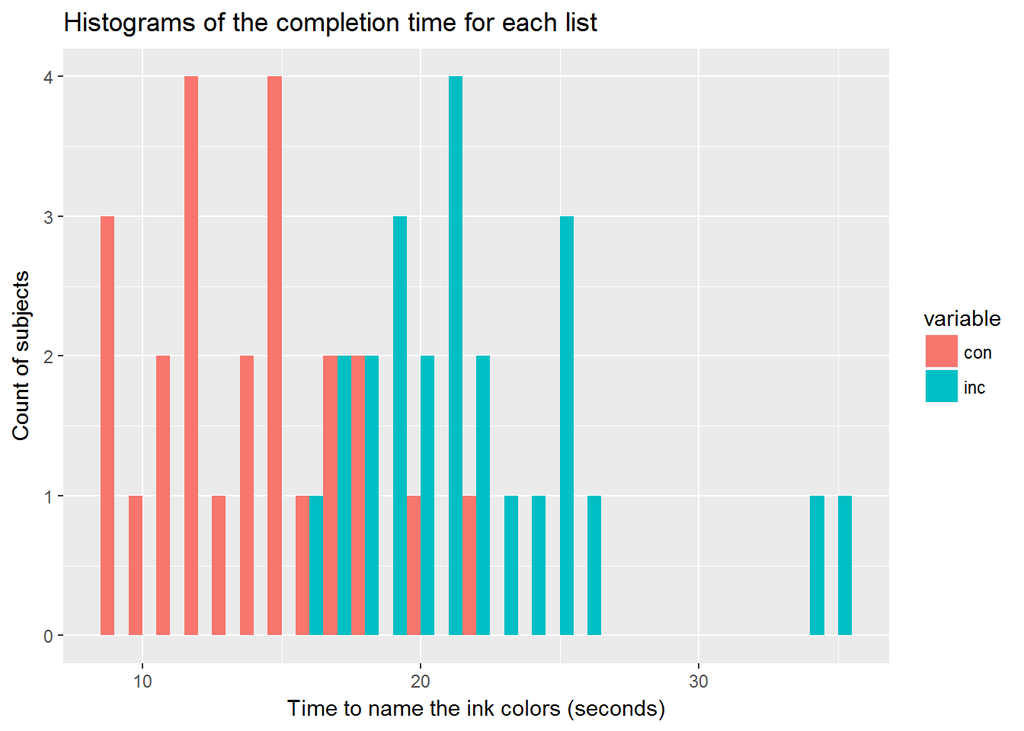

```r
#melt first for the histogram
t2 = melt(t, id=(c("id")))
t3 = subset(t2,(variable !='d'))
hist1 = ggplot(data = t3, aes(x = value, fill=variable)) +
  geom_histogram(binwidth = 1, position="dodge") +
  ylab('Count of subjects') +
  xlab('Time to name the ink colors (seconds)') +
  ggtitle('Histograms of the completion time for each list')
print (hist1)
```

#### Comments: Pretty obvious that the completion time for the incongruent list is “right-shifted” in comparison to the congruent list.

### Question 5: Perform the statistical test and interpret your results

#### I will conduct t-test’s both manually and using the packaged function just for fun.

```r
#Manual T-test
dlen = length(d)
t$sqrd = (d - dmu)^2
dstd = sqrt(sum(t$sqrd)/(dlen-1)) #standard deviation of differences
dse = dstd / sqrt(dlen) #standard error of differences
dcohend = dmu/dstd #Cohen's D - measure of effect size
tstat = dmu / dse

tcrit = qt(0.99,dlen - 1) #paired test, so df = n - 1 not n - 2 as for two sample tests
pvalue = 1 - pt(tstat,dlen - 1)
r2 = tstat^2 / (tstat^2 + dlen - 1)

#Packaged T-test
ttest = t.test(inc,con, alternative="greater", mu = 0, paired=TRUE, conf.level=0.99)
tstat2 = round(ttest$statistic,4)
pvalue2 = ttest$p.value
conf2 = round(ttest$conf.int,4)
```

#### A5: Conclusion - please see the output from R below

```
## [1] "Q: Is the t-statistic larger than t-critical value at 99% confidence level?"
```

```
## [1] "A: TRUE  - t-statistic is  8.0207 and t-critical value is 2.49986673949467"
```

```
## [1] "P-value is 2.05150029285558e-08"
```

```
## [1] "Confidence interval for the true population mean difference is between 5.4824 and Inf"
```

```
## [1] "Which means that we expect the average person similar to our average subject to have a delay of at least 5.4824 seconds for such a task."
```

#### Since the t-statistic is larger than the t-critical value at the 99% confidence, we reject H0: that there no differences in the time to name ink colors in the population from which the subjects were sampled. In other words, if there actually was no difference in the population, less 1% of the random samples of subjects drawn from it would look like the sample we have examined. Since this is a very rare occurence, I am pretty convinced that the results from this test are not due to chance. Indeed, the incongruency in the word’s meaning and the color of the ink is associated with more mental effort and, therefore, longer brain processing times. The results from this test confirm my initial expectations.

### Q6. What does the Stroop test really prove?

#### A6: The human brain is a very complex organic computer. Like any other computer, it is not immune to interferences, distractions, exhaustion. What the Stroop effect shows is that conflicting information affects the brain’s ability to respond and complete tasks. The more complex and contradictory the information, the more mental effort and time it takes to process and reconcile the information in order to complete the tasks.

#### One example that I have sometimes found myself in is the wrong names on the “hot” and “cold” faucets. It takes considerable effort to re-program the brain to turn on the “cold” faucet when what you really want is hot water. In general, pretty much any multi-tasking involving different projects would lead to similiar delays in response as well.